# Run simulations in R

## Overview

I find it helpful to use R simulations to help understand statistical concepts.

For example, one thing we want to emphasize is the difference between the distribution of a single random variable and the distrubtion of a sample statistic. We can use simulations to highlight their differences.

## Simulate the distribution of a single random

To simulate the distribution of a single random variable, we simply draw a large i.i.d. sample from that distribution and look at its histogram.

Suppose we want to see the distribution of a Gamma random variable $Y \sim Gamma(\alpha=2, \beta=5)$, where $\alpha$ and $\beta$ are the so-called shape and scale parameters for the Gamma distirbution.

We can draw a sample of size $n_{sim}=10000$ from `Gamma(2, 5)` distribution (use the `rgamma` function) and then look at its histrogram:

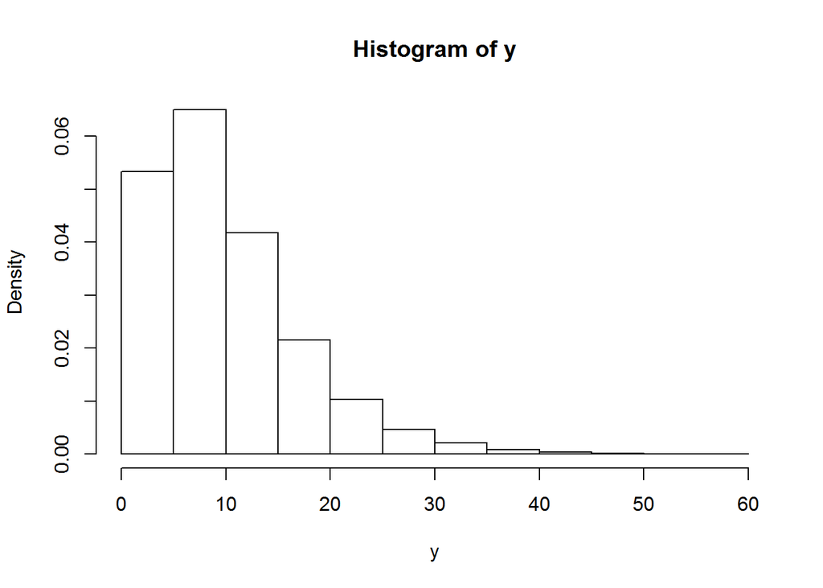

```r
## Specify the simulation sample size
n_sim = 10000;

## Draw a random sample from the gamma distribution with the specified parameters
y = rgamma(n_sim, shape=2, scale=5);

## Draw the histogram
hist(y, probability = TRUE);
```

For the gamma random variable, since we know its true desnity function. We can overlay the true density of this gamma distribution to verify that our simulation is a good approximation:

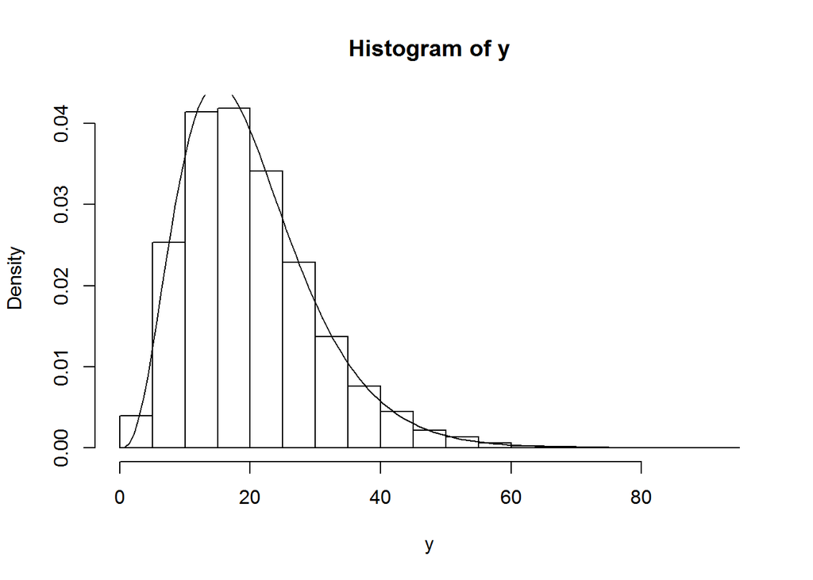

```r
## Specify the simulation sample size
n_sim = 10000;

## Draw a random sample from the gamma distribution with the specified parameters
y = rgamma(n_sim, shape=4, scale=5);

## Draw the histogram
hist(y, probability = TRUE);

## Create a grid of points
grid = seq(0, 70, length=100);

## Overlay the true density curve
lines(grid, dgamma(grid, shape=4, scale=5));
```

```r
mean(y);
```

```
## [1] 20.07124
```

```r
var(y);
```

```
## [1] 103.8578
```

## Simulate the distribution of a sample statistic

To simulate the distribution of a sample statistic, we need to **repeatedly draw random sample of specified size and compute the sample statistic for each random sample.**

For example, in the following R code, we simulate the distribution of the sample mean of a sample of size 5 from an exponential distribution:

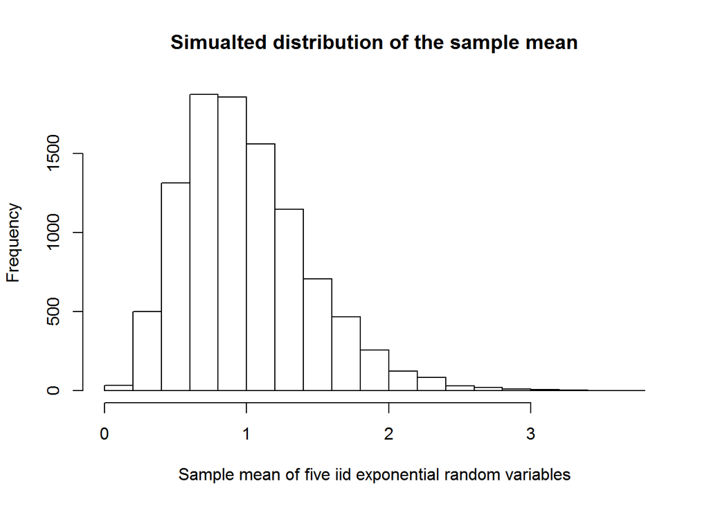

```r
## Specify the sample size
n = 5;

## Specify how many times you want to simulate the sampling procedure and compute the sample mean
n_sim = 10000;

## Create an array to save the result from each simulation
m = numeric(n_sim);

## Now draw samples, and compute the sample statistics:
for (i in 1:n_sim) {
  ## Draw sample from an exponential distribution with rate parameter 2.
  y = rexp(n);

  ## Compute the sample mean
  m[i] = mean(y);
}

## The histogram of the simulated sample means
hist(m, main="Simualted distribution of the sample mean",
     xlab="Sample mean of five iid exponential random variables")
```

I used a for loop in above R code. This is not the most computationally efficient way, but it is easy to understand.

Note that the distribution of the sample mean above is very different from the distribution of a single exponential random variable below:

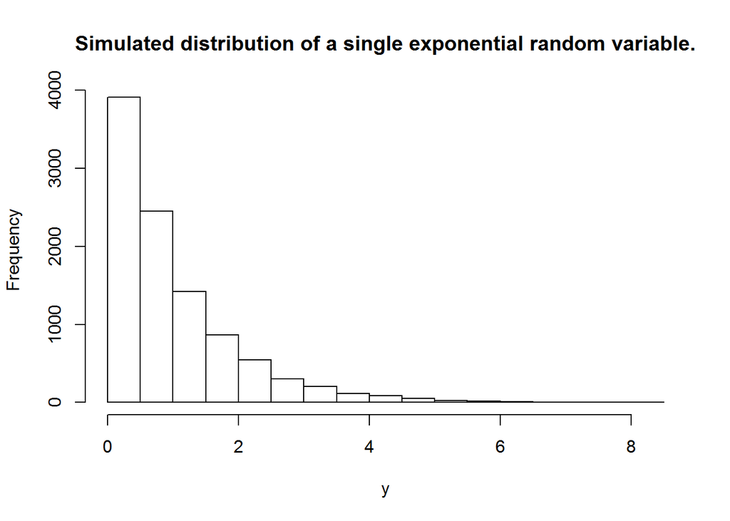

```r
## Sample from the exponential distribution 10000 times
y = rexp(10000);

## Show the histogram of the sample values
hist(y,
     main="Simulated distribution of a single exponential random variable.");
```

### Exercies:

- Simulate the distribution of other sample statsitics: e.g., sample variance
- Simulate the sample statistic from other distributions:
  - In R, you can draw random samples from other distributions: simply replace the `rexp` line in the above code by `rgamma`, `rnorm`, `runif`, `rbinom`, `rpois`, etc. Note each function will ask for model specific parameters: for exmaple, for `rbinom`, you need to specify $(n, p)$; for `rnorm`, you need to specify `mean` and `sd`.
- In R, type ? to find help on a command and use args() to find out more on how to call an R function:

```r
? rgamma

args(rgamma);
```

## The central limit theorem

The central limit theorem says the sample mean for i.i.d. samples are approximately normally distributed for “large” samples. Or the standardized statistic
$$\sqrt n \dfrac{\bar y - \mu}{\sigma}$$
approaches a standard normal distribution $N(0,1)$.

Now for the same expoential disribution, we will try different sample sizes and see how well the normal approximation works for different sample sizes ($n=3, 5, 10, 20, 30, 100$).

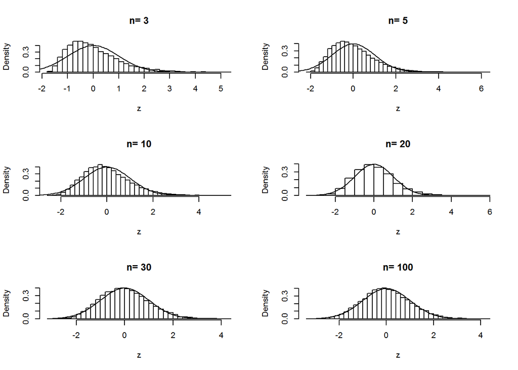

```r
## Tell R to draw six panels in one plot
par(mfrow=c(3,2));

## Specify simulation size
n_sim = 10000;

## For an Exp(1) random variable, mu=1, sigma=1
mu = 1;
sigma = 1;

## Specify the sample sizes in the outer loop
for (n in c(3, 5, 10, 20, 30, 100)) {

  ## Create arrays to save the results from each simulation
  m = numeric(n_sim);
  z = numeric(n_sim);

  ## Now draw samples, compute the sample mean
  for (i in 1:n_sim) {

    ## Draw sample from an exponential distribution
    y = rexp(n);

    ## Compute the sample mean
    m[i] = mean(y);

    ## Compute the standardized statistic
    z[i] = sqrt(n)* (m[i] - mu)/sigma

  }

  ## Histogram of the simulated sample means
  hist(z, probability =TRUE, main=sprintf("n= %d", n), nclass=30);

  ## Overlay a normal density curve
  x = seq(-3, 3, length=100);
  lines(x, dnorm(x));

}
```